[figure not shown]

# Preliminares

### Carga de paquetes

```r
library(pacman)
p_load(readxl,dplyr,vctrs,caret,FSinR,FSelector,arm, rpart, MASS, kernlab, elasticnet, mlbench, Boruta)
```

### Limpieza previa

**Archivo: 06 - datos1.xlsx**

Es un conjunto de datos sintético que contiene 31 registros y 11 variables

X_A: atributo numérico positivo

X_B: atributo numérico positivo

X_C: atributo numérico positivo

Y_A: atributo cualitativo que toma los valores SI y NO

Y_B: atributo cualitativo que toma los valores SI y NO

Y_C: atributo cualitativo que toma los valores SI y NO

z1: proporción (valores entre 0 y 1)

Z2: proporción (valores entre 0 y 1)

z3: proporción (valores entre 0 y 1)

Z4: proporción (valores entre 0 y 1)

Z5: proporción (valores entre 0 y 1)

```r
datos <- read_xlsx('06 - datos1.xlsx')
datos |> colnames()
```

```
 [1] "X_A" "X_B" "X_C" "Y_A" "Y_B" "Y_C" "z1"  "Z2"  "z3"  "Z4"  "Z5"
```

# Criterio fijado por el investigador

#### Función select

```r
datos[,c(1,3)] # Selecciona las columnas 1 y 3
```

```
# A tibble: 31 × 2
     X_A   X_C
   <dbl> <dbl>
 1    20    18
 2    17    11
 3    20    11
 4     4     3
 5    20     5
 6     7    20
 7    10    10
 8     8     7
 9    16    17
10     6     1
# ℹ 21 more rows
```

```r
datos[,seq(2,8,3)] # Selecciona las columnas 2, 5, 8
```

```
# A tibble: 31 × 3
     X_B Y_B       Z2
   <dbl> <chr>  <dbl>
 1    10 NO    0.890
 2    20 SI    0.403
 3    20 NO    0.918
 4    10 SI    0.334
 5     8 SI    0.657
 6    14 NO    0.454
 7    14 NO    0.0263
 8    14 SI    0.128
 9    17 SI    0.189
10     9 NO    0.882
# ℹ 21 more rows
```

```r
datos |> dplyr::select(X_A) # Selecciona la columna X_A
```

```
# A tibble: 31 × 1
     X_A
   <dbl>
 1    20
 2    17
 3    20
 4     4
 5    20
 6     7
 7    10
 8     8
 9    16
10     6
# ℹ 21 more rows
```

```r
datos |> dplyr::select(X_A:Y_A) # Selecciona las columnas X_A hasta Y_A
```

```
# A tibble: 31 × 4
     X_A   X_B   X_C Y_A
   <dbl> <dbl> <dbl> <chr>
 1    20    10    18 SI
 2    17    20    11 NO
 3    20    20    11 SI
 4     4    10     3 SI
 5    20     8     5 SI
 6     7    14    20 NO
 7    10    14    10 SI
 8     8    14     7 NO
 9    16    17    17 SI
10     6     9     1 SI
# ℹ 21 more rows
```

```r
datos |> dplyr::select(-(X_C:Y_B)) # Selecciona las columnas hasta X_B y de Y_C en adelante
```

```
# A tibble: 31 × 8
     X_A   X_B Y_C       z1     Z2    z3     Z4    Z5
   <dbl> <dbl> <chr>  <dbl>  <dbl> <dbl>  <dbl> <dbl>
 1    20    10 SI    0.478  0.890  0.806 0.579  0.995
 2    17    20 NO    0.561  0.403  0.802 0.0843 0.279
 3    20    20 SI    0.621  0.918  0.593 0.646  0.409
 4     4    10 NO    0.392  0.334  0.563 0.294  0.699
 5    20     8 SI    0.627  0.657  0.160 0.499  0.301
 6     7    14 SI    0.0808 0.454  0.185 0.713  0.766
 7    10    14 NO    0.557  0.0263 0.537 0.223  0.915
 8     8    14 SI    0.805  0.128  0.841 0.330  0.405
 9    16    17 SI    0.983  0.189  0.959 0.500  0.387
10     6     9 NO    0.906  0.882  0.238 0.562  0.729
# ℹ 21 more rows
```

```r
datos |> dplyr::select(starts_with("X")) # Selecciona las columnas que comienzan por X
```

```
# A tibble: 31 × 3
     X_A   X_B   X_C
   <dbl> <dbl> <dbl>
 1    20    10    18
 2    17    20    11
 3    20    20    11
 4     4    10     3
 5    20     8     5
 6     7    14    20
 7    10    14    10
 8     8    14     7
 9    16    17    17
10     6     9     1
# ℹ 21 more rows
```

```r
datos |> dplyr::select(starts_with(c("x","z"))) # Selecciona columnas que comienzan por x o z
```

```
# A tibble: 31 × 8
     X_A   X_B   X_C     z1     Z2    z3     Z4    Z5
   <dbl> <dbl> <dbl>  <dbl>  <dbl> <dbl>  <dbl> <dbl>
 1    20    10    18 0.478  0.890  0.806 0.579  0.995
 2    17    20    11 0.561  0.403  0.802 0.0843 0.279
 3    20    20    11 0.621  0.918  0.593 0.646  0.409
 4     4    10     3 0.392  0.334  0.563 0.294  0.699
 5    20     8     5 0.627  0.657  0.160 0.499  0.301
 6     7    14    20 0.0808 0.454  0.185 0.713  0.766
 7    10    14    10 0.557  0.0263 0.537 0.223  0.915
 8     8    14     7 0.805  0.128  0.841 0.330  0.405
 9    16    17    17 0.983  0.189  0.959 0.500  0.387
10     6     9     1 0.906  0.882  0.238 0.562  0.729
# ℹ 21 more rows
```

```r
datos |> dplyr::select(ends_with("b")) # Selecciona columnas que terminan con b o B
```

```
# A tibble: 31 × 2
     X_B Y_B
   <dbl> <chr>
 1    10 NO
 2    20 SI
 3    20 NO
 4    10 SI
 5     8 SI
 6    14 NO
 7    14 NO
 8    14 SI
 9    17 SI
10     9 NO
# ℹ 21 more rows
```

```r
datos |> dplyr::select(!ends_with("a")) # Selecciona columnas que no terminan con a
```

```
# A tibble: 31 × 9
     X_B   X_C Y_B   Y_C       z1     Z2    z3     Z4    Z5
   <dbl> <dbl> <chr> <chr>  <dbl>  <dbl> <dbl>  <dbl> <dbl>
 1    10    18 NO    SI    0.478  0.890  0.806 0.579  0.995
 2    20    11 SI    NO    0.561  0.403  0.802 0.0843 0.279
 3    20    11 NO    SI    0.621  0.918  0.593 0.646  0.409
 4    10     3 SI    NO    0.392  0.334  0.563 0.294  0.699
 5     8     5 SI    SI    0.627  0.657  0.160 0.499  0.301
 6    14    20 NO    SI    0.0808 0.454  0.185 0.713  0.766
 7    14    10 NO    NO    0.557  0.0263 0.537 0.223  0.915
 8    14     7 SI    SI    0.805  0.128  0.841 0.330  0.405
 9    17    17 SI    SI    0.983  0.189  0.959 0.500  0.387
10     9     1 NO    NO    0.906  0.882  0.238 0.562  0.729
# ℹ 21 more rows
```

```r
datos |> dplyr::select(starts_with("X") | ends_with("b")) # selecciona columnas que comienzan con X o terminan con b
```

```
# A tibble: 31 × 4
     X_A   X_B   X_C Y_B
   <dbl> <dbl> <dbl> <chr>
 1    20    10    18 NO
 2    17    20    11 SI
 3    20    20    11 NO
 4     4    10     3 SI
 5    20     8     5 SI
 6     7    14    20 NO
 7    10    14    10 NO
 8     8    14     7 SI
 9    16    17    17 SI
10     6     9     1 NO
# ℹ 21 more rows
```

```r
datos |> dplyr::select(starts_with("X") & ends_with("b")) # selecciona columnas que comienzan con X y terminan con b
```

```
# A tibble: 31 × 1
     X_B
   <dbl>
 1    10
 2    20
 3    20
 4    10
 5     8
 6    14
 7    14
 8    14
 9    17
10     9
# ℹ 21 more rows
```

```r
datos |> dplyr::select(contains("_")) # Selecciona columnas que contengan _
```

```
# A tibble: 31 × 6
     X_A   X_B   X_C Y_A   Y_B   Y_C
   <dbl> <dbl> <dbl> <chr> <chr> <chr>
 1    20    10    18 SI    NO    SI
 2    17    20    11 NO    SI    NO
 3    20    20    11 SI    NO    SI
 4     4    10     3 SI    SI    NO
 5    20     8     5 SI    SI    SI
 6     7    14    20 NO    NO    SI
 7    10    14    10 SI    NO    NO
 8     8    14     7 NO    SI    SI
 9    16    17    17 SI    SI    SI
10     6     9     1 SI    NO    NO
# ℹ 21 more rows
```

```r
datos |> dplyr::select(everything()) # selecciona todas las columnas
```

```
# A tibble: 31 × 11
     X_A   X_B   X_C Y_A   Y_B   Y_C       z1     Z2    z3     Z4    Z5
   <dbl> <dbl> <dbl> <chr> <chr> <chr>  <dbl>  <dbl> <dbl>  <dbl> <dbl>
 1    20    10    18 SI    NO    SI    0.478  0.890  0.806 0.579  0.995
 2    17    20    11 NO    SI    NO    0.561  0.403  0.802 0.0843 0.279
 3    20    20    11 SI    NO    SI    0.621  0.918  0.593 0.646  0.409
 4     4    10     3 SI    SI    NO    0.392  0.334  0.563 0.294  0.699
 5    20     8     5 SI    SI    SI    0.627  0.657  0.160 0.499  0.301
 6     7    14    20 NO    NO    SI    0.0808 0.454  0.185 0.713  0.766
 7    10    14    10 SI    NO    NO    0.557  0.0263 0.537 0.223  0.915
 8     8    14     7 NO    SI    SI    0.805  0.128  0.841 0.330  0.405
 9    16    17    17 SI    SI    SI    0.983  0.189  0.959 0.500  0.387
10     6     9     1 SI    NO    NO    0.906  0.882  0.238 0.562  0.729
# ℹ 21 more rows
```

#### Funciones derivadas de select

```r
datos |> dplyr::select_all() # selecciona todas las columnas
```

```
# A tibble: 31 × 11
     X_A   X_B   X_C Y_A   Y_B   Y_C       z1     Z2    z3     Z4    Z5
   <dbl> <dbl> <dbl> <chr> <chr> <chr>  <dbl>  <dbl> <dbl>  <dbl> <dbl>
 1    20    10    18 SI    NO    SI    0.478  0.890  0.806 0.579  0.995
 2    17    20    11 NO    SI    NO    0.561  0.403  0.802 0.0843 0.279
 3    20    20    11 SI    NO    SI    0.621  0.918  0.593 0.646  0.409
 4     4    10     3 SI    SI    NO    0.392  0.334  0.563 0.294  0.699
 5    20     8     5 SI    SI    SI    0.627  0.657  0.160 0.499  0.301
 6     7    14    20 NO    NO    SI    0.0808 0.454  0.185 0.713  0.766
 7    10    14    10 SI    NO    NO    0.557  0.0263 0.537 0.223  0.915
 8     8    14     7 NO    SI    SI    0.805  0.128  0.841 0.330  0.405
 9    16    17    17 SI    SI    SI    0.983  0.189  0.959 0.500  0.387
10     6     9     1 SI    NO    NO    0.906  0.882  0.238 0.562  0.729
# ℹ 21 more rows
```

```r
datos |> dplyr::select_if(is.numeric) # selecciona las columnas numéricas
```

```
# A tibble: 31 × 8
     X_A   X_B   X_C     z1     Z2    z3     Z4    Z5
   <dbl> <dbl> <dbl>  <dbl>  <dbl> <dbl>  <dbl> <dbl>
 1    20    10    18 0.478  0.890  0.806 0.579  0.995
 2    17    20    11 0.561  0.403  0.802 0.0843 0.279
 3    20    20    11 0.621  0.918  0.593 0.646  0.409
 4     4    10     3 0.392  0.334  0.563 0.294  0.699
 5    20     8     5 0.627  0.657  0.160 0.499  0.301
 6     7    14    20 0.0808 0.454  0.185 0.713  0.766
 7    10    14    10 0.557  0.0263 0.537 0.223  0.915
 8     8    14     7 0.805  0.128  0.841 0.330  0.405
 9    16    17    17 0.983  0.189  0.959 0.500  0.387
10     6     9     1 0.906  0.882  0.238 0.562  0.729
# ℹ 21 more rows
```

```r
datos |> dplyr::select_if(is.integer) # selecciona las columnas de tipo entero
```

```
# A tibble: 31 × 0
```

```r
datos |> dplyr::select_if(is.double) # selecciona las columnas de tipo double
```

```
# A tibble: 31 × 8
     X_A   X_B   X_C     z1     Z2    z3     Z4    Z5
   <dbl> <dbl> <dbl>  <dbl>  <dbl> <dbl>  <dbl> <dbl>
 1    20    10    18 0.478  0.890  0.806 0.579  0.995
 2    17    20    11 0.561  0.403  0.802 0.0843 0.279
 3    20    20    11 0.621  0.918  0.593 0.646  0.409
 4     4    10     3 0.392  0.334  0.563 0.294  0.699
 5    20     8     5 0.627  0.657  0.160 0.499  0.301
 6     7    14    20 0.0808 0.454  0.185 0.713  0.766
 7    10    14    10 0.557  0.0263 0.537 0.223  0.915
 8     8    14     7 0.805  0.128  0.841 0.330  0.405
 9    16    17    17 0.983  0.189  0.959 0.500  0.387
10     6     9     1 0.906  0.882  0.238 0.562  0.729
# ℹ 21 more rows
```

```r
datos |> dplyr::select_if(is.character) # selecciona las columnas de tipo character
```

```
# A tibble: 31 × 3
   Y_A   Y_B   Y_C
   <chr> <chr> <chr>
 1 SI    NO    SI
 2 NO    SI    NO
 3 SI    NO    SI
 4 SI    SI    NO
 5 SI    SI    SI
 6 NO    NO    SI
 7 SI    NO    NO
 8 NO    SI    SI
 9 SI    SI    SI
10 SI    NO    NO
# ℹ 21 more rows
```

```r
datos |> dplyr::select_if(is.logical) # selecciona las columnas de tipo logico
```

```
# A tibble: 31 × 0
```

```r
datos |> dplyr::select_at(vars(contains("X"),starts_with("Z")),tolower)
```

```
# A tibble: 31 × 8
     x_a   x_b   x_c     z1     z2    z3     z4    z5
   <dbl> <dbl> <dbl>  <dbl>  <dbl> <dbl>  <dbl> <dbl>
 1    20    10    18 0.478  0.890  0.806 0.579  0.995
 2    17    20    11 0.561  0.403  0.802 0.0843 0.279
 3    20    20    11 0.621  0.918  0.593 0.646  0.409
 4     4    10     3 0.392  0.334  0.563 0.294  0.699
 5    20     8     5 0.627  0.657  0.160 0.499  0.301
 6     7    14    20 0.0808 0.454  0.185 0.713  0.766
 7    10    14    10 0.557  0.0263 0.537 0.223  0.915
 8     8    14     7 0.805  0.128  0.841 0.330  0.405
 9    16    17    17 0.983  0.189  0.959 0.500  0.387
10     6     9     1 0.906  0.882  0.238 0.562  0.729
# ℹ 21 more rows
```

```r
datos |> dplyr::select_at(vars(contains("Z"),starts_with("X")),toupper)
```

```
# A tibble: 31 × 8
       Z1     Z2    Z3     Z4    Z5   X_A   X_B   X_C
    <dbl>  <dbl> <dbl>  <dbl> <dbl> <dbl> <dbl> <dbl>
 1 0.478  0.890  0.806 0.579  0.995    20    10    18
 2 0.561  0.403  0.802 0.0843 0.279    17    20    11
 3 0.621  0.918  0.593 0.646  0.409    20    20    11
 4 0.392  0.334  0.563 0.294  0.699     4    10     3
 5 0.627  0.657  0.160 0.499  0.301    20     8     5
 6 0.0808 0.454  0.185 0.713  0.766     7    14    20
 7 0.557  0.0263 0.537 0.223  0.915    10    14    10
 8 0.805  0.128  0.841 0.330  0.405     8    14     7
 9 0.983  0.189  0.959 0.500  0.387    16    17    17
10 0.906  0.882  0.238 0.562  0.729     6     9     1
# ℹ 21 more rows
```

#### Selección de variables por fuerza bruta

```r
p = 3
S=0;for(i in 0:p){S=S+choose(p,i)};S
```

```
[1] 8
```

```r
2^p
```

```
[1] 8
```

```r
p = datos |> ncol()
choose(p,3)
```

```
[1] 165
```

```r
S=0;for(i in 0:11){S=S+choose(p,i)};S
```

```
[1] 2048
```

```r
2^p
```

```
[1] 2048
```

```r
p = 40
S=0;for(i in 0:p){S=S+choose(p,i)};S
```

```
[1] 1.099512e+12
```

```r
2^p
```

```
[1] 1.099512e+12
```

# Direccionalidad de la búsqueda

**data: GermanCredit**

1000 personas clasificadas como personas de riesgo crediticio o no

Variable respuesta: Class: 1: Bueno, 2: Malo

Duration: Duración, en meses, del último préstamo

Amount: Monto de crédito

InstallmentRatePercentage: Tasa de pago a plazos en porcentaje de la renta disponible

ResidenceDuration: Número de años en la residencia actual

Age: Edad, en años

NumberExistingCredits: Número de créditos en el banco, etc

```r
data(GermanCredit)
datos6 = GermanCredit |>
  dplyr::select(Duration,Amount,InstallmentRatePercentage,
                ResidenceDuration,Age,NumberExistingCredits,Class)
```

#### Selección directa

```r
Busqueda_KMejores  <- directSearchAlgorithm(directSearcher = "selectKBest", list(k = 2))
Busqueda_KMejores  <- selectKBest(k = 2) # esta línea y la anterior son equivalentes
Busqueda_Percentil <- directSearchAlgorithm(directSearcher = "selectPercentile", list(percentile = 40))
Busqueda_Percentil <- selectPercentile(percentile = 40) # esta línea y la anterior son equivalentes
```

#### Búsqueda óptima

```r
Busqueda_BFS   <- searchAlgorithm(searcher = "breadthFirst")
Busqueda_BFS   <- breadthFirst() # esta línea y la anterior son equivalentes
Busqueda_DFS   <- deepFirst()
```

#### Búsqueda secuencial

```r
Busqueda_SFS   <- searchAlgorithm(searcher = "sequentialForwardSelection")
Busqueda_SFS   <- sequentialForwardSelection() # esta línea y la anterior son equivalentes
Busqueda_SBS   <- sequentialBackwardSelection()
Busqueda_SFFS  <- sequentialFloatingForwardSelection()
Busqueda_SFBS  <- sequentialFloatingBackwardSelection()
```

#### Búsqueda probabilística

```r
Busqueda_LV    <- LasVegas()
```

#### Búsqueda local

```r
Busqueda_HC    <- hillClimbing()
```

#### Búsqueda metaheurística

```r
Busqueda_Tabu  <- tabu()
Busqueda_AntC  <- antColony()
Busqueda_GA    <- geneticAlgorithm()
Busqueda_SA    <- simulatedAnnealing()
Busqueda_Whale <- whaleOptimization()
```

# Filtros

### Filtros individuales

#### Medidas de atributos individuales

```r
Evaluador_Cramer <- filterEvaluator(filter = 'cramer')
Evaluador_Cramer <- cramer() # esta línea y la anterior son equivalentes
Evaluador_Cramer(datos6, 'Class', 'Duration')
```

```
[1] 0.2808682
```

```r
Evaluador_Cramer(datos6, 'Class', 'Amount')
```

```
[1] 0.9652699
```

```r
Evaluador_Cramer(datos6, 'Class', 'Age')
```

```
[1] 0.2397444
```

```r
Evaluador_Cramer(datos6, 'Class', 'InstallmentRatePercentage')
```

```
[1] 0.07400535
```

```r
Evaluador_Cramer(datos6, 'Class', 'NumberExistingCredits')
```

```
[1] 0.05168364
```

```r
directFeatureSelection(datos6, 'Class', Busqueda_KMejores, Evaluador_Cramer)$bestFeatures
```

```
     Duration Amount InstallmentRatePercentage ResidenceDuration Age
[1,]        1      1                         0                 0   0
     NumberExistingCredits
[1,]                     0
```

```r
directFeatureSelection(datos6, 'Class', Busqueda_Percentil, Evaluador_Cramer)$bestFeatures
```

```
     Duration Amount InstallmentRatePercentage ResidenceDuration Age
[1,]        1      1                         0                 0   0
     NumberExistingCredits
[1,]                     0
```

```r
directFeatureSelection(datos6, 'Class', Busqueda_Percentil, Evaluador_Cramer)$featuresSelected
```

```
[1] "Amount"   "Duration"
```

```r
directFeatureSelection(datos6, 'Class', Busqueda_Percentil, Evaluador_Cramer)$featuresSelected |>
  as.simple.formula('Class')
```

```
Class ~ Amount + Duration
<environment: 0x00000225fb0a06e0>
```

En resumen, debe definirise el data frame, la variable dependiente de clase, el algoritmo de búsqueda y el filtro, por ejemplo:

```r
busqueda_kmejores <- selectKBest(k = 2)  # algoritmo de búsqueda
evaluador_cramer  <- cramer()            # filtro
directFeatureSelection(datos6, 'Class', busqueda_kmejores, evaluador_cramer)$bestFeatures
```

```
     Duration Amount InstallmentRatePercentage ResidenceDuration Age
[1,]        1      1                         0                 0   0
     NumberExistingCredits
[1,]                     0
```

```r
directFeatureSelection(datos6, 'Class', busqueda_kmejores, evaluador_cramer)$time
```

```
   user  system elapsed
      0       0       0
```

```r
busqueda_kmejores <- selectKBest(k = 2)  # algoritmo de búsqueda
Evaluador_Chi2    <- chiSquared()        # filtro del paquete FSinR
directFeatureSelection(datos6, 'Class', Busqueda_KMejores, Evaluador_Chi2)$bestFeatures
```

```
     Duration Amount InstallmentRatePercentage ResidenceDuration Age
[1,]        1      1                         0                 0   0
     NumberExistingCredits
[1,]                     0
```

```r
directFeatureSelection(datos6, 'Class', Busqueda_KMejores, Evaluador_Chi2)$time
```

```
   user  system elapsed
      0       0       0
```

```r
indicadores <- chi.squared(Class~., datos6) # filtro en el paquete FSelector
indicadores |> print()
```

```
                          attr_importance
Duration                        0.1775827
Amount                          0.1641730
InstallmentRatePercentage       0.0000000
ResidenceDuration               0.0000000
Age                             0.0000000
NumberExistingCredits           0.0000000
```

```r
indicadores |> cutoff.k(2)
```

```
[1] "Duration" "Amount"
```

```r
indicadores |> cutoff.k(2) |> as.simple.formula("Class")
```

```
Class ~ Duration + Amount
<environment: 0x00000225f6500460>
```

**Medidas de atributos individuales: chiSquared, cramer, fscore**

#### Medidas de conjuntos de atributos

```r
Evaluador_Relief <- FSinR::relief() # indicar nombre de paquete para no confundir con otro relief
directFeatureSelection(datos6, 'Class', Busqueda_Percentil, Evaluador_Relief)$bestFeatures
```

```
     Duration Amount InstallmentRatePercentage ResidenceDuration Age
[1,]        1      1                         0                 0   0
     NumberExistingCredits
[1,]                     0
```

```r
directFeatureSelection(datos6, 'Class', Busqueda_Percentil, Evaluador_Relief)$time
```

```
   user  system elapsed
   8.79    0.11    9.34
```

**Medida de conjuntos de atributos: relief**

### Filtros colectivos

```r
# featureSelection(datos6, 'Class', Busqueda_SFS, Evaluador_Cramer)  # error

Evaluador_Gini <- giniIndex() # filtro de gini
result1 <- featureSelection(datos6, 'Class', Busqueda_SFS, Evaluador_Gini)
result2 <- featureSelection(datos6, 'Class', Busqueda_SFFS, Evaluador_Gini)
result3 <- featureSelection(datos6, 'Class', Busqueda_SBS, Evaluador_Gini)
result4 <- featureSelection(datos6, 'Class', Busqueda_SFBS, Evaluador_Gini)
result5 <- featureSelection(datos6, 'Class', Busqueda_BFS, Evaluador_Gini)
result6 <- featureSelection(datos6, 'Class', Busqueda_Tabu, Evaluador_Gini)
result1$bestFeatures
```

```
     Duration Amount InstallmentRatePercentage ResidenceDuration Age
[1,]        0      1                         0                 0   1
     NumberExistingCredits
[1,]                     0
```

```r
result2$bestFeatures
```

```
     Duration Amount InstallmentRatePercentage ResidenceDuration Age
[1,]        0      1                         0                 0   1
     NumberExistingCredits
[1,]                     0
```

```r
result3$bestFeatures
```

```
     Duration Amount InstallmentRatePercentage ResidenceDuration Age
[1,]        0      1                         0                 0   1
     NumberExistingCredits
[1,]                     0
```

```r
result4$bestFeatures
```

```
     Duration Amount InstallmentRatePercentage ResidenceDuration Age
[1,]        0      1                         0                 0   1
     NumberExistingCredits
[1,]                     0
```

```r
result5$bestFeatures
```

```
     Duration Amount InstallmentRatePercentage ResidenceDuration Age
[1,]        0      1                         0                 0   1
     NumberExistingCredits
[1,]                     0
```

```r
result6$bestFeatures
```

```
     Duration Amount InstallmentRatePercentage ResidenceDuration Age
[1,]        0      1                         0                 0   1
     NumberExistingCredits
[1,]                     0
```

```r
result1$time
```

```
   user  system elapsed
   2.98    0.08    3.40
```

```r
result2$time
```

```
   user  system elapsed
   4.31    0.06    4.51
```

```r
result3$time
```

```
   user  system elapsed
   3.10    0.05    3.31
```

```r
result4$time
```

```
   user  system elapsed
   5.40    0.07    5.61
```

```r
result5$time
```

```
   user  system elapsed
   6.40    0.05    6.78
```

```r
result6$time
```

```
   user  system elapsed
  61.68    1.38   66.46
```

¿Si el conjunto de variables es unitario?

```r
Evaluador_Gini(datos6, 'Class', 'Duration')
```

```
[1] 0.6131325
```

```r
Evaluador_Gini(datos6, 'Class', 'Amount')
```

```
[1] 0.9713333
```

```r
Evaluador_Gini(datos6, 'Class', 'Age')
```

```
[1] 0.6041405
```

```r
Evaluador_Gini(datos6, 'Class', 'InstallmentRatePercentage')
```

```
[1] 0.5823003
```

```r
Evaluador_Gini(datos6, 'Class', 'ResidenceDuration')
```

```
[1] 0.5803147
```

```r
Evaluador_Gini(datos6, 'Class', 'NumberExistingCredits')
```

```
[1] 0.5811219
```

En vez de Evaluador_Gini, se pueden utilizar otros criterios de filtro para conjunto de variables: medidas de consistencia, de dependencia, de distancia.

Se puede buscar en la ayuda ?filterEvaluator

```r
Evaluador_Gini <- filterEvaluator(filter = 'giniIndex') # filtro con medida de información
Evaluador_RSC  <- filterEvaluator(filter = 'roughsetConsistency') # filtro con medida de consistencia
Evaluador_R2   <- filterEvaluator(filter = 'determinationCoefficient') # filtro con medida de dependencia
```

**Medidas de conjuntos de atributos**

- binaryConsistency - de consistencia
- determinationCoefficient - de dependencia (para atributos continuos)
- gainRatio - de información
- giniIndex - de información (para atributos discretos)
- IEConsistency - de consistencia
- Jd - de información
- MDLC - de información
- mutualInformation - de información
- roughsetConsistency - de consistencia
- ReliefFeatureSetMeasure - de distancia o separabilidad
- symmetricalUncertain - de información

Medida de consistencia usando FSelector::consistency

```r
(subset <- consistency(Class~., datos6))
```

```
[1] "Duration"
```

```r
as.simple.formula(subset, "Class")
```

```
Class ~ Duration
<environment: 0x00000225fa041e18>
```

Más sobre FSelector: https://cran.r-project.org/web/packages/FSelector/FSelector.pdf

### Filtros híbridos

```r
Busqueda_Hibrida <- hybridSearchAlgorithm('LCC')           # búsqueda
Evaluador_Chi2   <- filterEvaluator(filter = 'chiSquared') # filtro individual
Evaluador_Gini   <- filterEvaluator(filter = 'giniIndex')  # filtro colectivo
#  hybridFeatureSelection(datos6, 'Class', Busqueda_Hibrida, Evaluador_Gini, Evaluador_Chi2) # error
hybridFeatureSelection(datos6, 'Class', Busqueda_Hibrida, Evaluador_Chi2, Evaluador_Gini) # (indiv, colect)
```

```
$bestFeatures
     Duration Amount InstallmentRatePercentage ResidenceDuration Age
[1,]        0      1                         0                 0   0
     NumberExistingCredits
[1,]                     0

$bestValue
[1] 0.9713333

$evaluationType_1
[1] "Filter"

$evaluationMethod_1
[1] "Chi Squared"

$measureType_1
[1] "Individual measure"

$evaluationType_2
[1] "Filter"

$evaluationMethod_2
[1] "Gini Index"

$measureType_2
[1] "Set measure"

$searchMethod
[1] "Linear Consistency-Constrained"

$target
[1] "maximize"

$numFeatures
[1] 6

$xNames
[1] "Duration"                  "Amount"
[3] "InstallmentRatePercentage" "ResidenceDuration"
[5] "Age"                       "NumberExistingCredits"

$yName
[1] "Class"

$time
   user  system elapsed
   0.86    0.00    0.94
```

```r
# hybridFeatureSelection(datos6, 'Class', Busqueda_Hibrida, Evaluador_Chi2, Evaluador_Chi2) # error
hybridFeatureSelection(datos6, 'Class', Busqueda_Hibrida, Evaluador_Gini, Evaluador_Gini) # (colect, colect)
```

```
$bestFeatures
     Duration Amount InstallmentRatePercentage ResidenceDuration Age
[1,]        0      1                         0                 0   0
     NumberExistingCredits
[1,]                     0

$bestValue
[1] 0.9713333

$evaluationType_1
[1] "Filter"

$evaluationMethod_1
[1] "Gini Index"

$measureType_1
[1] "Set measure"

$evaluationType_2
[1] "Filter"

$evaluationMethod_2
[1] "Gini Index"

$measureType_2
[1] "Set measure"

$searchMethod
[1] "Linear Consistency-Constrained"

$target
[1] "maximize"

$numFeatures
[1] 6

$xNames
[1] "Duration"                  "Amount"
[3] "InstallmentRatePercentage" "ResidenceDuration"
[5] "Age"                       "NumberExistingCredits"

$yName
[1] "Class"

$time
   user  system elapsed
   1.05    0.01    1.19
```

El orden debe ser (data frame, variable Y, algoritmo hibrido, filtro ind o conj, filtro conj)

# Envolturas (wrappers)

```r
Evaluador_bglm <- wrapperEvaluator(learner          = "bayesglm",
                                   resamplingParams = list(method = "repeatedcv",
                                                           repeats = 3))
resultado_bglm <- featureSelection(datos6, 'Class', Busqueda_SFS, Evaluador_bglm)
resultado_bglm$bestFeatures
```

```
     Duration Amount InstallmentRatePercentage ResidenceDuration Age
[1,]        0      1                         1                 1   1
     NumberExistingCredits
[1,]                     0
```

```r
resultado_bglm$time
```

```
   user  system elapsed
  10.79    0.08   11.81
```

resamplingParams permite definir los mismos argumentos que trainControl en caret

fittingParams permite indicar valores para tuning de hiperparámetros

no todos los métodos / modelos tienen hiperparámetros

```r
validacion    <- list(method = "repeatedcv", repeats = 10)
Evaluador_lda <- wrapperEvaluator(learner          = 'lda',
                                  resamplingParams = validacion)
resultado_lda <- featureSelection(datos6, 'Class', Busqueda_SFS, Evaluador_lda)
resultado_lda$bestFeatures
```

```
     Duration Amount InstallmentRatePercentage ResidenceDuration Age
[1,]        1      1                         1                 1   1
     NumberExistingCredits
[1,]                     1
```

```r
resultado_lda$time
```

```
   user  system elapsed
  16.44    0.30   17.94
```

```r
validacion    <- list(method = "repeatedcv", repeats = 3)
tuning        <- list(tuneGrid = expand.grid(k = c(1:12)))
Evaluador_KNN <- wrapperEvaluator(learner          = "knn",
                                  resamplingParams = validacion,
                                  fittingParams    = tuning)
resultado_knn <- featureSelection(datos6, 'Class', Busqueda_SFFS, Evaluador_KNN)
resultado_knn$bestFeatures
```

```
     Duration Amount InstallmentRatePercentage ResidenceDuration Age
[1,]        1      0                         0                 0   0
     NumberExistingCredits
[1,]                     0
```

```r
resultado_knn$time
```

```
   user  system elapsed
  74.47    0.78   78.95
```

```r
validacion      <- list(method = "repeatedcv", repeats = 5)
tuning          <- list(tuneGrid = expand.grid(cp = seq(0,0.1,0.01)))
Evaluador_rpart <- wrapperEvaluator(learner          = 'rpart',
                                    resamplingParams = validacion,
                                    fittingParams    = tuning)
resultado_rpart <- featureSelection(datos6, 'Class', Busqueda_SFS, Evaluador_rpart)
resultado_rpart$bestFeatures
```

```
     Duration Amount InstallmentRatePercentage ResidenceDuration Age
[1,]        0      1                         1                 1   0
     NumberExistingCredits
[1,]                     1
```

```r
resultado_rpart$time
```

```
   user  system elapsed
  42.76    0.70   48.67
```

```r
tuning       <- list(tuneGrid = expand.grid(mtry = round(sqrt(ncol(datos6)))),
                     trace    = FALSE)
Evaluador_rf <- wrapperEvaluator(learner = 'rf',
                                 fittingParams = tuning)
resultado_rf <- featureSelection(datos6, 'Class', Busqueda_SFS, Evaluador_rf)
resultado_rf$bestFeatures
```

```
     Duration Amount InstallmentRatePercentage ResidenceDuration Age
[1,]        0      0                         0                 1   0
     NumberExistingCredits
[1,]                     1
```

```r
resultado_rf$time
```

```
   user  system elapsed
 155.54    9.81  184.11
```

Otros métodos de envoltura: Recursive Feature Elimination, RFE (caret::rfeControl)

# BORUTA

```r
boruta <- Boruta(Class ~ ., data = datos6, doTrace = 0, maxRuns = 200)
boruta |> print()
```

```
Boruta performed 199 iterations in 43.72318 secs.
 3 attributes confirmed important: Age, Amount, Duration;
 1 attributes confirmed unimportant: NumberExistingCredits;
 2 tentative attributes left: InstallmentRatePercentage,
ResidenceDuration;
```

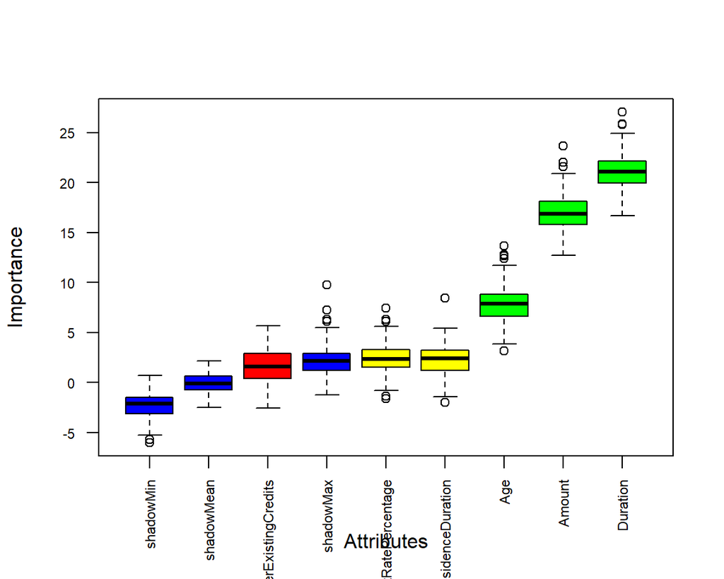

```r
boruta |> plot(las = 2, cex.axis = 0.7)
```

```r
boruta |> attStats()
```

```
                            meanImp medianImp    minImp    maxImp  normHits
Duration                  21.106073 21.108715 16.676833 27.059376 1.0000000
Amount                    16.967147 16.876653 12.742839 23.668917 1.0000000
InstallmentRatePercentage  2.384483  2.334471 -1.630384  7.478178 0.5577889
ResidenceDuration          2.210219  2.395992 -1.990132  8.452112 0.5427136
Age                        7.908878  7.897294  3.155914 13.644706 0.9949749
NumberExistingCredits      1.635671  1.590310 -2.545552  5.705011 0.3216080
                           decision
Duration                  Confirmed
Amount                    Confirmed
InstallmentRatePercentage Tentative
ResidenceDuration         Tentative
Age                       Confirmed
NumberExistingCredits      Rejected
```

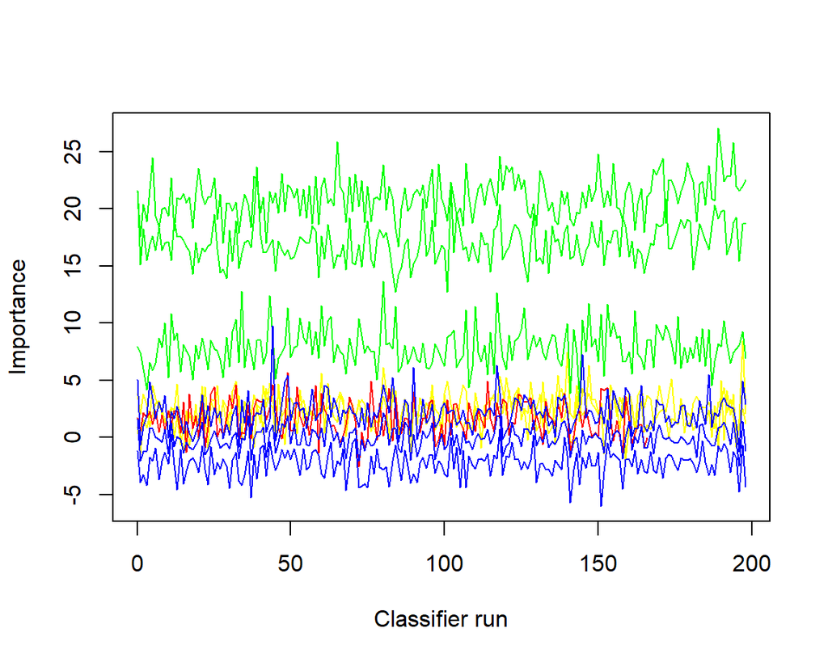

```r
boruta |> plotImpHistory()
```

```r
boruta$timeTaken
```

```
Time difference of 43.72318 secs
```

```r
boruta2 <- Boruta(Class ~ ., data = datos6, doTrace = 0, maxRuns = 1500)
boruta2 |> print()
```

```
Boruta performed 1499 iterations in 5.019925 mins.
 4 attributes confirmed important: Age, Amount, Duration,
ResidenceDuration;
 1 attributes confirmed unimportant: NumberExistingCredits;
 1 tentative attributes left: InstallmentRatePercentage;
```

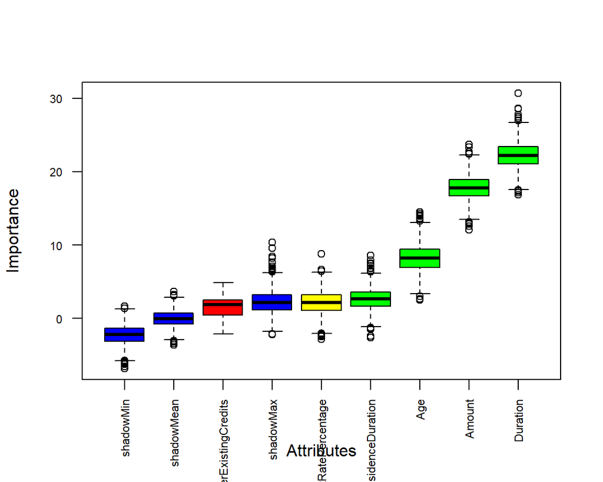

```r
boruta2 |> plot(las = 2, cex.axis = 0.7)
```

```r
boruta2 |> attStats()
```

```
                            meanImp medianImp    minImp    maxImp   normHits
Duration                  22.192189 22.207959 16.835913 30.693343 1.00000000
Amount                    17.791981 17.763704 12.090157 23.713525 1.00000000
InstallmentRatePercentage  2.174214  2.188331 -2.843860  8.797613 0.50300200
ResidenceDuration          2.636379  2.646157 -2.600258  8.592581 0.58372248
Age                        8.242382  8.217616  2.478700 14.498941 0.99666444
NumberExistingCredits      1.596286  1.891338 -2.138243  4.883566 0.01801201
                           decision
Duration                  Confirmed
Amount                    Confirmed
InstallmentRatePercentage Tentative
ResidenceDuration         Confirmed
Age                       Confirmed
NumberExistingCredits      Rejected
```

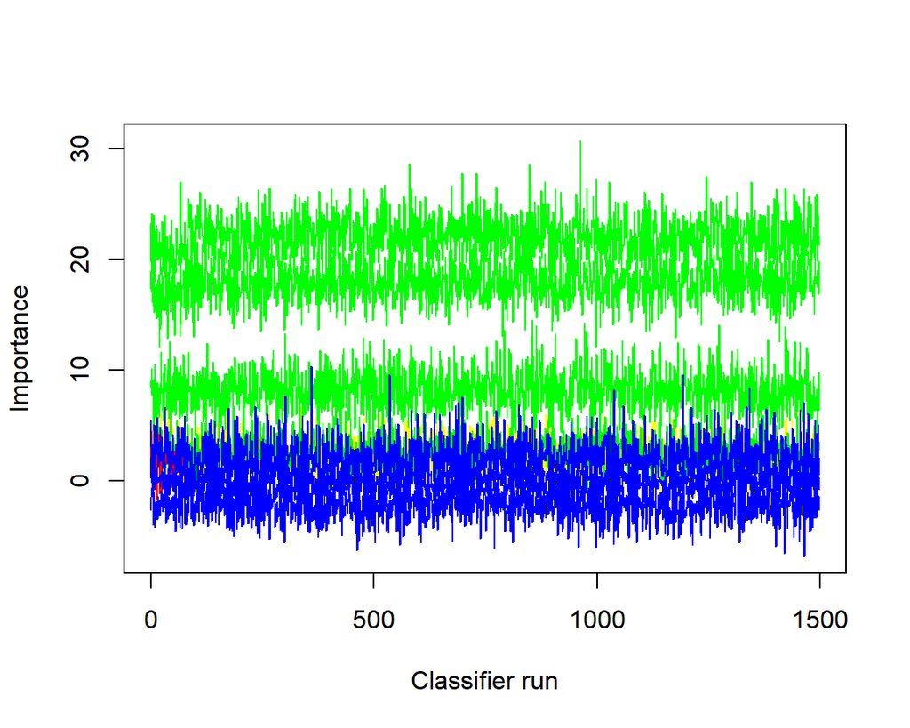

```r
boruta2 |> plotImpHistory()
```

```r
boruta2$timeTaken
```

```
Time difference of 5.019925 mins
```

```r
boruta3<- Boruta(Class ~ ., data = datos6, doTrace = 0, maxRuns = 1500, pValue = 0.01/10)
boruta3 |> print()
```

```
Boruta performed 1499 iterations in 5.433672 mins.
 4 attributes confirmed important: Age, Amount, Duration,
ResidenceDuration;
 1 attributes confirmed unimportant: NumberExistingCredits;
 1 tentative attributes left: InstallmentRatePercentage;
```

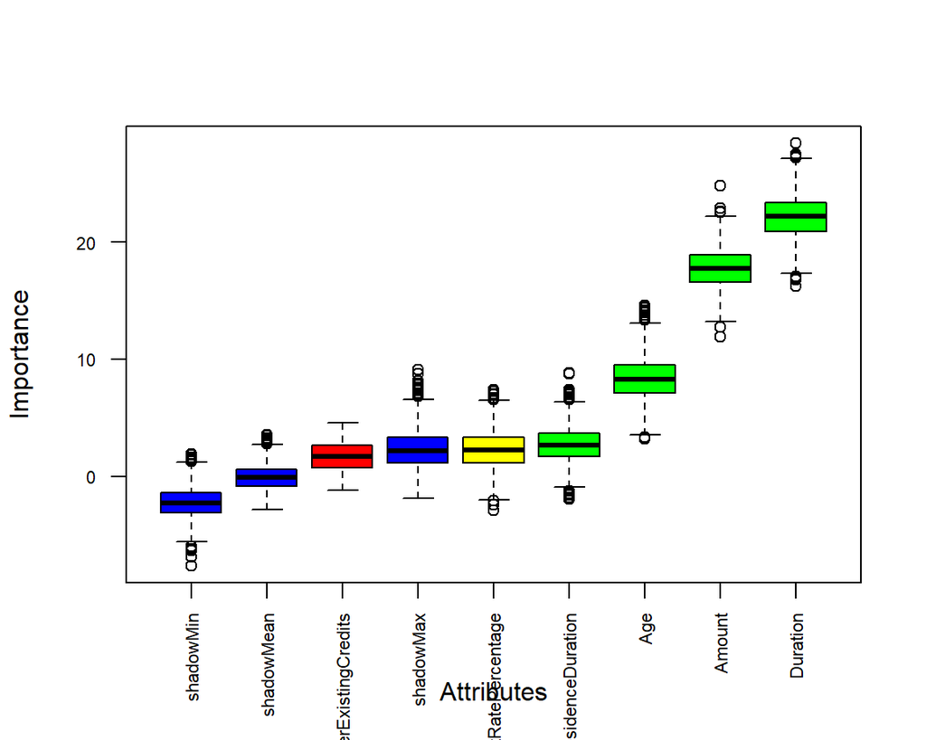

```r
boruta3 |> plot(las = 2, cex.axis = 0.7)
```

```r
boruta3 |> attStats()
```

```
                            meanImp medianImp    minImp    maxImp  normHits
Duration                  22.170849 22.198202 16.264952 28.458894 1.0000000
Amount                    17.759386 17.774110 11.936368 24.836021 1.0000000
InstallmentRatePercentage  2.290255  2.274224 -2.935947  7.422297 0.5083389
ResidenceDuration          2.676334  2.648493 -1.930155  8.820320 0.5890594
Age                        8.342174  8.276421  3.213698 14.626835 0.9959973
NumberExistingCredits      1.731646  1.724593 -1.212670  4.583978 0.0527018
                           decision
Duration                  Confirmed
Amount                    Confirmed
InstallmentRatePercentage Tentative
ResidenceDuration         Confirmed
Age                       Confirmed
NumberExistingCredits      Rejected
```

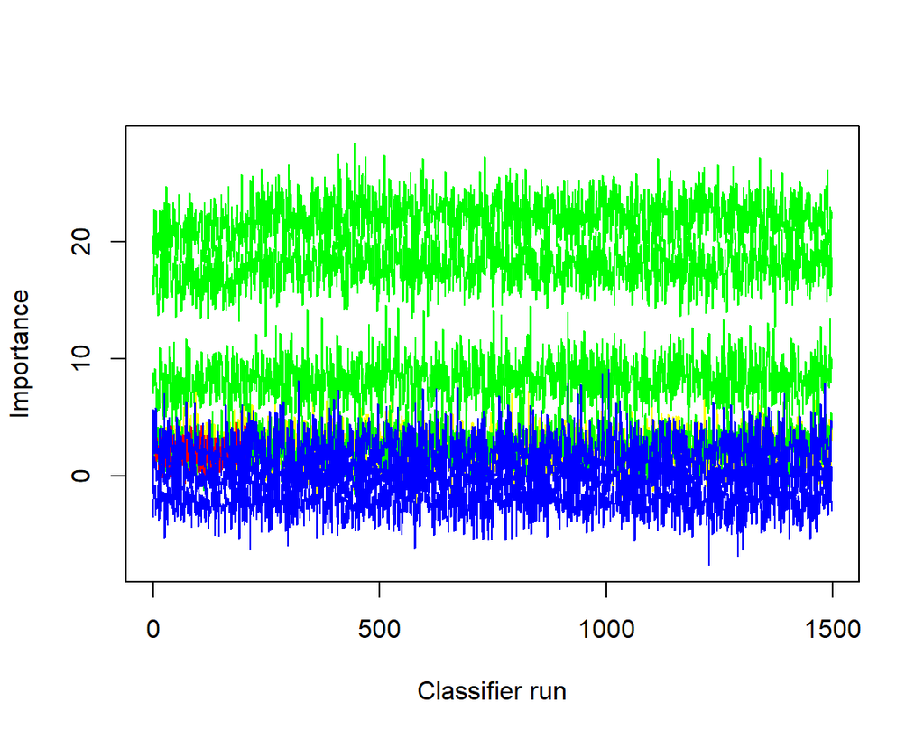

```r
boruta3 |> plotImpHistory()
```

```r
boruta3$timeTaken
```

```
Time difference of 5.433672 mins
```

```r
boruta4 <- boruta |> TentativeRoughFix()
boruta4 |> print()
```

```
Boruta performed 199 iterations in 43.72318 secs.
Tentatives roughfixed over the last 199 iterations.
 5 attributes confirmed important: Age, Amount, Duration,
InstallmentRatePercentage, ResidenceDuration;
 1 attributes confirmed unimportant: NumberExistingCredits;
```

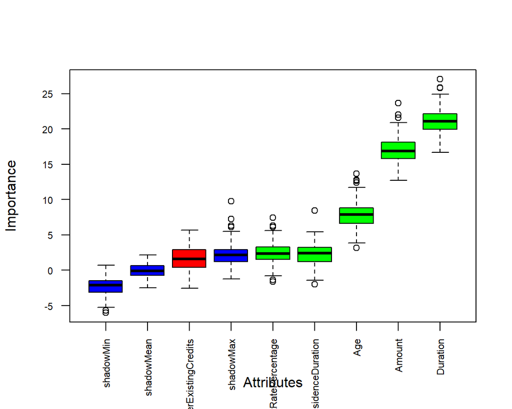

```r
boruta4 |> plot(las = 2, cex.axis = 0.7)
```

```r
boruta4 |> attStats()
```

```
                            meanImp medianImp    minImp    maxImp  normHits
Duration                  21.106073 21.108715 16.676833 27.059376 1.0000000
Amount                    16.967147 16.876653 12.742839 23.668917 1.0000000
InstallmentRatePercentage  2.384483  2.334471 -1.630384  7.478178 0.5577889
ResidenceDuration          2.210219  2.395992 -1.990132  8.452112 0.5427136
Age                        7.908878  7.897294  3.155914 13.644706 0.9949749
NumberExistingCredits      1.635671  1.590310 -2.545552  5.705011 0.3216080
                           decision
Duration                  Confirmed
Amount                    Confirmed
InstallmentRatePercentage Confirmed
ResidenceDuration         Confirmed
Age                       Confirmed
NumberExistingCredits      Rejected
```

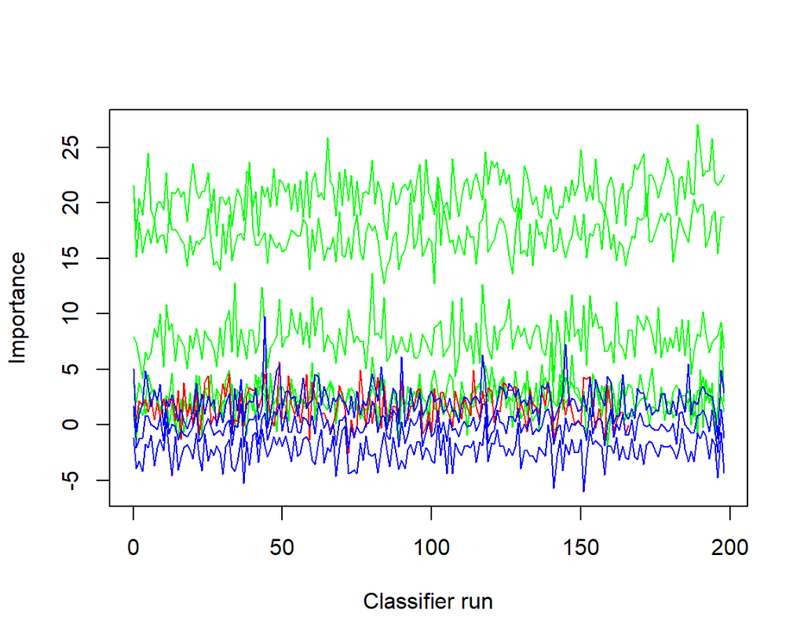

```r
boruta4 |> plotImpHistory()
```

```r
boruta4$originalDecision
```

```
                 Duration                    Amount InstallmentRatePercentage
                Confirmed                 Confirmed                 Tentative
        ResidenceDuration                       Age     NumberExistingCredits
                Tentative                 Confirmed                  Rejected
Levels: Tentative Confirmed Rejected
```

```r
boruta4$finalDecision
```

```
                 Duration                    Amount InstallmentRatePercentage
                Confirmed                 Confirmed                 Confirmed
        ResidenceDuration                       Age     NumberExistingCredits
                Confirmed                 Confirmed                  Rejected
Levels: Tentative Confirmed Rejected
```